# Final Project

Jia Williams

# COVID-19 Cases, Hospitalizations, and Deaths Across Race

For this project, I’m seeking to explore the differing experiences of COVID-19 based on racial identity and state of residence. A lack of equitable healthcare infrastructure, types of employment, and location are all factors that can and have contributed to the disproportionate impact of COVID-19 on racial and ethnic minorities in the United States. This is evidenced by CDC data showing that Native Hawaiian or Pacific Island (NHOPI), Hispanic, and American Indian and Alaska Native (AIAN) people face a 1.5 times higher right of COVID-19 infection that White people. In addition, AIAN, Hispanic, NHOPI and Black people face a 2x higher likelihood of death than White people from COVID-19 infections. Compounding racial disparities are differences in state response to the pandemic.The extent of COVID-19 protection measures varied greatly by state, depending on factors such as the state’s political leanings and attitudes of leadership regarding the pandemic. Some states saw more lenient regulations vs others, which ultimately resulted in significantly different experiences with COVID-19. At times, these factors, compounded by pre-existing genetic conditions related to race, have contributed to heightened rates of infection, hospitalization, and deaths within these vulnerable communities. In this project, I’d like to do a deeper dive into the extent of the experience gap between these marginalized communities and white communities through variables such as location and race.

The data I’m using comes from a collaboration between The Covid Tracking Project at The Atlantic and the Boston University Center for Antiracist Research. It tracks data from April 15, 2020 to March 7, 2021, so almost a full year of data at the height of the pandemic. The data was then updated twice a week.

### Data Cleaning

```r
data <- read_csv("CovidRace.csv")
acs <- read_csv("ACSDP5Y2020.DP05-Data.csv")
saveRDS(data, "data.rds")

# remove all rows without a total number of cases
# remove all territories (Puerto Rico, Northern Mariana Islands, Guam, Virgin Islands) for just the 50 states and Washington D.C.

data <- data %>% filter(
  !is.na(Cases_Total),
  !State %in% c("PR","MP","GU","VI"))

data <- data %>%
  mutate(date1 = ymd(Date))
```

### Normalization for Population

Here I’m pulling the total population of each state, as well as population of each racial group for normalization purposes and renaming the variables to match the racial groups in the original data. Also adding postal codes so that I can join the two tables later.

```r
acs <- acs %>%
  select(GEO_ID, NAME, DP05_0001E, DP05_0037E, DP05_0038E, DP05_0039E, DP05_0044E, DP05_0052E, DP05_0057E, DP05_0058E, DP05_0070E) %>%
  filter(!NAME == "Puerto Rico", !GEO_ID == "Geography") %>%
  mutate(post_code = c("AL", "AK", "AZ", "AR", "CA", "CO", "CT", "DE", "DC", "FL", "GA", "HI", "ID", "IL", "IN", "IO", "KS", "KY", "LA", "ME", "MD", "MA", "MI", "MN", "MS", "MO", "MT", "NE", "NV", "NH",
"NJ", "NM", "NY", "NC", "ND", "OH", "OK", "OR", "PA", "RI", "SC", "SD", "TN", "TX", "UT", "VT", "VA", "WA", "WV", "WI", "WY"))

colnames(acs)[c(3:11)] <- c("Total_pop", "White_pop", "Black_pop", "AIAN_pop", "Asian_pop", "NHPI_pop", "Other_pop", "Multiracial_pop", "Latinx_pop")

### Joining the tables using postal code!

norm_data <- acs %>% select(-Total_pop) %>% # don't want to add the total to the other cases, so removing it
  left_join(data, by = c("post_code" = "State"))

norm_data_total <- acs %>%
  left_join(data, by = c("post_code" = "State"))

### Cases, hospitalizations, tests, and deaths normalized by population- without total cases

norm_data <- norm_data %>% mutate(
  White_cases_norm = Cases_White/as.numeric(White_pop),
  White_hosp_norm = Hosp_White/as.numeric(White_pop),
  White_tests_norm = Tests_White/as.numeric(White_pop),
  White_deaths_norm = Deaths_White/as.numeric(White_pop),
  Black_cases_norm = Cases_Black/as.numeric(Black_pop),
  Black_hosp_norm = Hosp_Black/as.numeric(Black_pop),
  Black_tests_norm = Tests_Black/as.numeric(Black_pop),
  Black_deaths_norm = Deaths_Black/as.numeric(Black_pop),
  AIAN_cases_norm = Cases_AIAN/as.numeric(AIAN_pop),
  AIAN_hosp_norm = Hosp_AIAN/as.numeric(AIAN_pop),
  AIAN_tests_norm = Tests_AIAN/as.numeric(AIAN_pop),
  AIAN_deaths_norm = Deaths_AIAN/as.numeric(AIAN_pop),
  Asian_cases_norm = Cases_Asian/as.numeric(Asian_pop),
  Asian_hosp_norm = Hosp_Asian/as.numeric(Asian_pop),
  Asian_tests_norm = Tests_Asian/as.numeric(Asian_pop),
  Asian_deaths_norm = Deaths_Asian/as.numeric(Asian_pop),
  NHPI_cases_norm = Cases_NHPI/as.numeric(NHPI_pop),
  NHPI_hosp_norm = Hosp_NHPI/as.numeric(NHPI_pop),
  NHPI_tests_norm = Tests_NHPI/as.numeric(NHPI_pop),
  NHPI_deaths_norm = Deaths_NHPI/as.numeric(NHPI_pop),
  Other_cases_norm = Cases_Other/as.numeric(Other_pop),
  Other_hosp_norm = Hosp_Other/as.numeric(Other_pop),
  Other_tests_norm = Tests_Other/as.numeric(Other_pop),
  Other_deaths_norm = Deaths_Other/as.numeric(Other_pop),
  Multiracial_cases_norm = Cases_Multiracial/as.numeric(Multiracial_pop),
  Multiracial_hosp_norm = Hosp_Multiracial/as.numeric(Multiracial_pop),
  Multiracial_tests_norm = Tests_Multiracial/as.numeric(Multiracial_pop),
  Multiracial_deaths_norm = Deaths_Multiracial/as.numeric(Multiracial_pop),
  Latinx_cases_norm = Cases_Latinx/as.numeric(Latinx_pop),
  Latinx_hosp_norm = Hosp_Latinx/as.numeric(Latinx_pop),
  Latinx_tests_norm = Tests_Latinx/as.numeric(Latinx_pop),
  Latinx_deaths_norm = Deaths_Latinx/as.numeric(Latinx_pop))

### Cases, hospitalizations, tests, and deaths normalized by population- With total cases

norm_data_total <- norm_data_total %>% mutate(
  Total_cases_norm = Cases_Total/as.numeric(Total_pop),
  White_cases_norm = Cases_White/as.numeric(White_pop),
  Black_cases_norm = Cases_Black/as.numeric(Black_pop),
  AIAN_cases_norm = Cases_AIAN/as.numeric(AIAN_pop),
  Asian_cases_norm = Cases_Asian/as.numeric(Asian_pop),
  NHPI_cases_norm = Cases_NHPI/as.numeric(NHPI_pop),
  Other_cases_norm = Cases_Other/as.numeric(Other_pop),
  Multiracial_cases_norm = Cases_Multiracial/as.numeric(Multiracial_pop),
  Latinx_cases_norm = Cases_Latinx/as.numeric(Latinx_pop),

  Total_hosp_norm = Hosp_Total/as.numeric(Total_pop),
  White_hosp_norm = Hosp_White/as.numeric(White_pop),
  Black_hosp_norm = Hosp_Black/as.numeric(Black_pop),
  AIAN_hosp_norm = Hosp_AIAN/as.numeric(AIAN_pop),
  Asian_hosp_norm = Hosp_Asian/as.numeric(Asian_pop),
  NHPI_hosp_norm = Hosp_NHPI/as.numeric(NHPI_pop),
  Other_hosp_norm = Hosp_Other/as.numeric(Other_pop),
  Multiracial_hosp_norm = Hosp_Multiracial/as.numeric(Multiracial_pop),
  Latinx_hosp_norm = Hosp_Latinx/as.numeric(Latinx_pop),

  Total_tests_norm = Tests_Total/as.numeric(Total_pop),
  White_tests_norm = Tests_White/as.numeric(White_pop),
  Black_tests_norm = Tests_Black/as.numeric(Black_pop),
  AIAN_tests_norm = Tests_AIAN/as.numeric(AIAN_pop),
  Asian_tests_norm = Tests_Asian/as.numeric(Asian_pop),
  NHPI_tests_norm = Tests_NHPI/as.numeric(NHPI_pop),
  Other_tests_norm = Tests_Other/as.numeric(Other_pop),
  Multiracial_tests_norm = Tests_Multiracial/as.numeric(Multiracial_pop),
  Latinx_tests_norm = Tests_Latinx/as.numeric(Latinx_pop),

  Total_deaths_norm = Deaths_Total/as.numeric(Total_pop),
  White_deaths_norm = Deaths_White/as.numeric(White_pop),
  Black_deaths_norm = Deaths_Black/as.numeric(Black_pop),
  AIAN_deaths_norm = Deaths_AIAN/as.numeric(AIAN_pop),
  Asian_deaths_norm = Deaths_Asian/as.numeric(Asian_pop),
  NHPI_deaths_norm = Deaths_NHPI/as.numeric(NHPI_pop),
  Other_deaths_norm = Deaths_Other/as.numeric(Other_pop),
  Multiracial_deaths_norm = Deaths_Multiracial/as.numeric(Multiracial_pop),
  Latinx_deaths_norm = Deaths_Latinx/as.numeric(Latinx_pop))
```

### Changing to long data type

```r
cases_long_norm_start <- norm_data_total %>%
  filter(date1 == as.Date("2020-04-15")) %>%
  select(post_code, Total_cases_norm:Latinx_cases_norm) %>%
  mutate(across(Total_cases_norm:Latinx_cases_norm, ~replace_na(.x, 0))) %>%
  pivot_longer(-post_code, names_to = "race", values_to = "cases",
               names_prefix = "Cases_")

cases_long_norm_end <- norm_data_total %>%
  filter(date1 == as.Date("2021-03-07")) %>%
  select(post_code, Total_cases_norm:Latinx_cases_norm) %>%
  mutate(across(Total_cases_norm:Latinx_cases_norm, ~replace_na(.x, 0))) %>%
  pivot_longer(-post_code, names_to = "race", values_to = "cases",
               names_prefix = "Cases_")
```

### Looking at the percentage of covid cases compared to overall population by state at the start of data collection and at the end

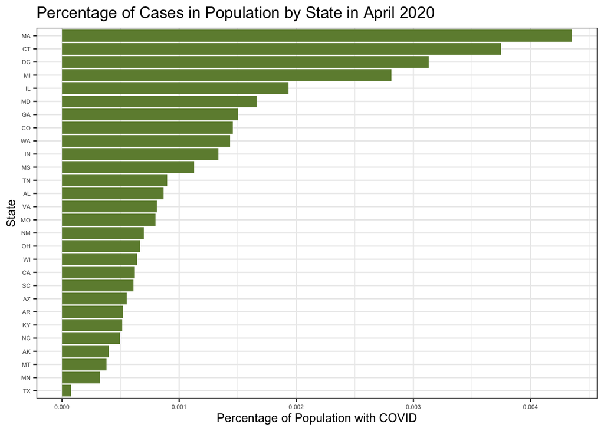

```r
cases_long_norm_start %>%
  filter(race == "Total_cases_norm") %>%
  ggplot(aes(y = fct_reorder(post_code, cases), x = cases)) +
  geom_col(fill = "darkolivegreen4") +
  labs(y = "State", x = "Percentage of Population with COVID", title = "Percentage of Cases in Population by State in April 2020") +
  theme(axis.title = element_text(size = 10),
        axis.text = element_text(size = 5))
```

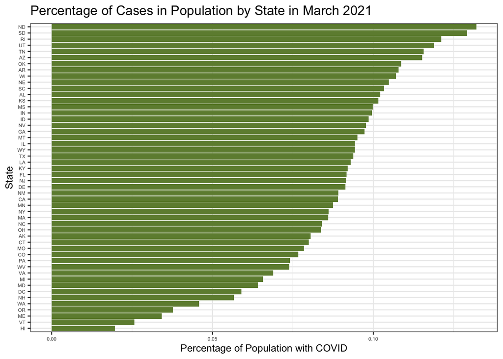

```r
cases_long_norm_end %>%
  filter(race == "Total_cases_norm") %>%
  ggplot(aes(y = fct_reorder(post_code, cases), x = cases)) +
  geom_col(fill = "darkolivegreen4") +
  labs(y = "State", x = "Percentage of Population with COVID", title = "Percentage of Cases in Population by State in March 2021") +
  theme(axis.title = element_text(size = 10),
        axis.text = element_text(size = 5))
```

### Comparing the proportion of cases by race in each state at the start of data collection and at the end

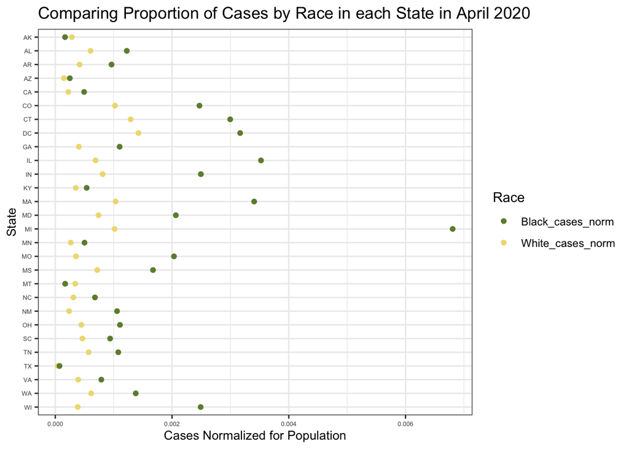

```r
bw_start <- cases_long_norm_start %>%
  filter(race %in% c("White_cases_norm", "Black_cases_norm")) %>%
  ggplot(aes(x = reorder(post_code, desc(post_code)), y = cases, color = race)) +
  geom_point() +
  coord_flip() +
  scale_color_manual("Race", values = c("darkolivegreen4", "lightgoldenrod2")) +
  labs(x = "State", y = "Cases Normalized for Population",
       title = "Comparing Proportion of Cases by Race in each State in April 2020") +
  theme(axis.title = element_text(size = 10),
        axis.text = element_text(size = 5))
bw_start
```

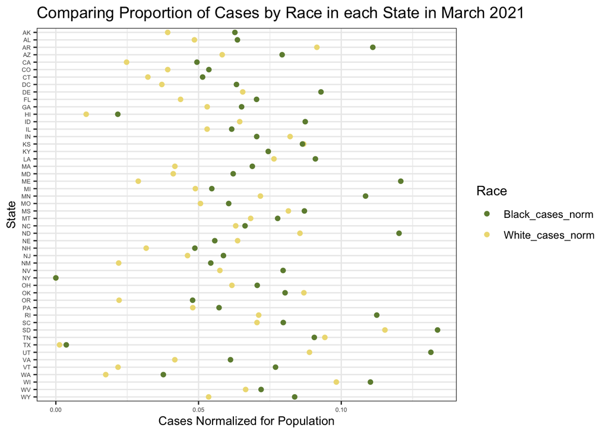

```r
bw_end <- cases_long_norm_end %>%
  filter(race %in% c("White_cases_norm", "Black_cases_norm")) %>%
  ggplot(aes(x = reorder(post_code, desc(post_code)), y = cases, color = race)) +
  geom_point() +
  coord_flip() +
  scale_color_manual("Race", values = c("darkolivegreen4", "lightgoldenrod2")) +
  labs(x = "State", y = "Cases Normalized for Population",
       title = "Comparing Proportion of Cases by Race in each State in March 2021") +
  theme(axis.title = element_text(size = 10),
        axis.text = element_text(size = 5))
bw_end
```

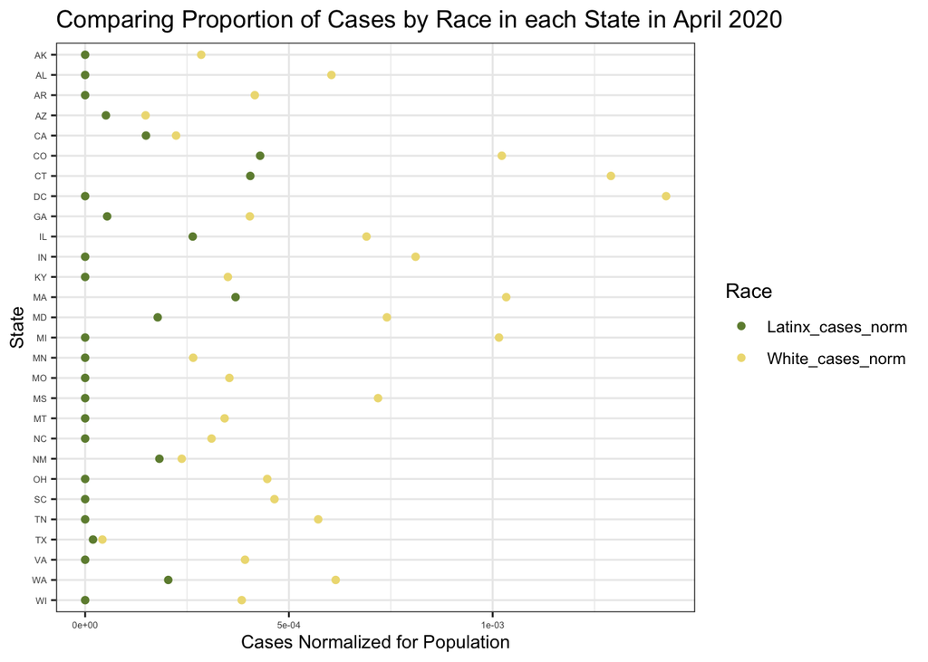

```r
lxw_start <- cases_long_norm_start %>%
  filter(race %in% c("White_cases_norm", "Latinx_cases_norm")) %>%
  ggplot(aes(x = reorder(post_code, desc(post_code)), y = cases, color = race)) +
  geom_point() +
  coord_flip() +
  scale_color_manual("Race", values = c("darkolivegreen4", "lightgoldenrod2")) +
  labs(x = "State", y = "Cases Normalized for Population",
       title = "Comparing Proportion of Cases by Race in each State in April 2020") +
  theme(axis.title = element_text(size = 10),
        axis.text = element_text(size = 5))
lxw_start
```

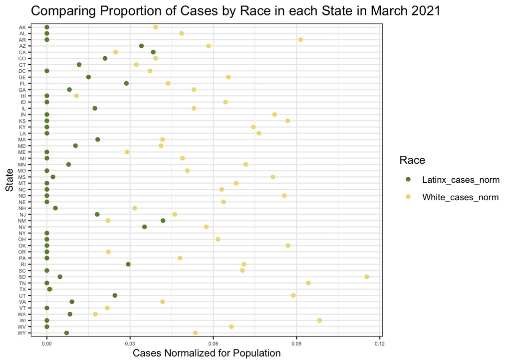

```r
lxw_end <- cases_long_norm_end %>%
  filter(race %in% c("White_cases_norm", "Latinx_cases_norm")) %>%
  ggplot(aes(x = reorder(post_code, desc(post_code)), y = cases, color = race)) +
  geom_point() +
  coord_flip() +
  scale_color_manual("Race", values = c("darkolivegreen4", "lightgoldenrod2")) +
  labs(x = "State", y = "Cases Normalized for Population",
       title = "Comparing Proportion of Cases by Race in each State in March 2021") +
  theme(axis.title = element_text(size = 10),
        axis.text = element_text(size = 5))
lxw_end
```

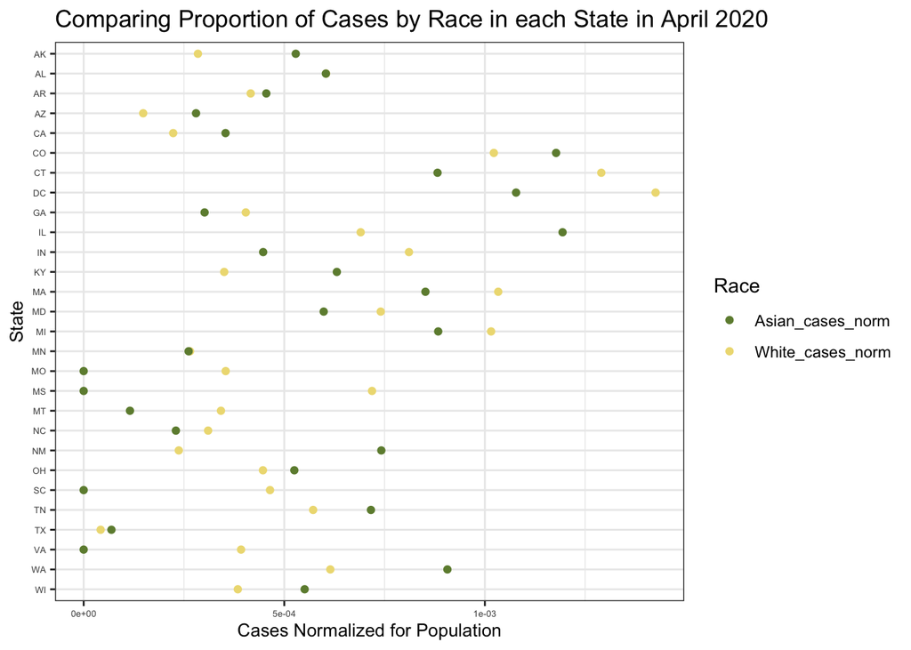

```r
aw_start <- cases_long_norm_start %>%
  filter(race %in% c("White_cases_norm", "Asian_cases_norm")) %>%
  ggplot(aes(x = reorder(post_code, desc(post_code)), y = cases, color = race)) +
  geom_point() +
  coord_flip() +
  scale_color_manual("Race", values = c("darkolivegreen4", "lightgoldenrod2")) +
  labs(x = "State", y = "Cases Normalized for Population",
       title = "Comparing Proportion of Cases by Race in each State in April 2020") +
  theme(axis.title = element_text(size = 10),
        axis.text = element_text(size = 5))
aw_start
```

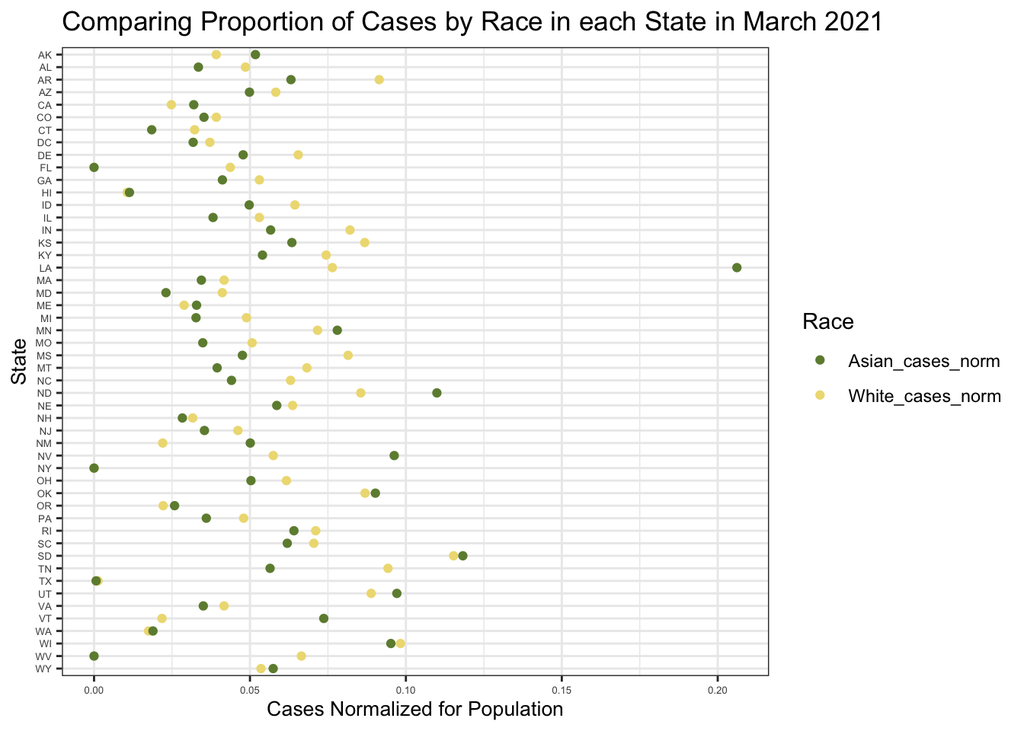

```r
aw_end <- cases_long_norm_end %>%
  filter(race %in% c("White_cases_norm", "Asian_cases_norm")) %>%
  ggplot(aes(x = reorder(post_code, desc(post_code)), y = cases, color = race)) +
  geom_point() +
  coord_flip() +
  scale_color_manual("Race", values = c("darkolivegreen4", "lightgoldenrod2")) +
  labs(x = "State", y = "Cases Normalized for Population",
       title = "Comparing Proportion of Cases by Race in each State in March 2021") +
  theme(axis.title = element_text(size = 10),
        axis.text = element_text(size = 5))
aw_end
```

### Comparing the demographic composition of cases to the demographic composition of the population using filled/stack bars.

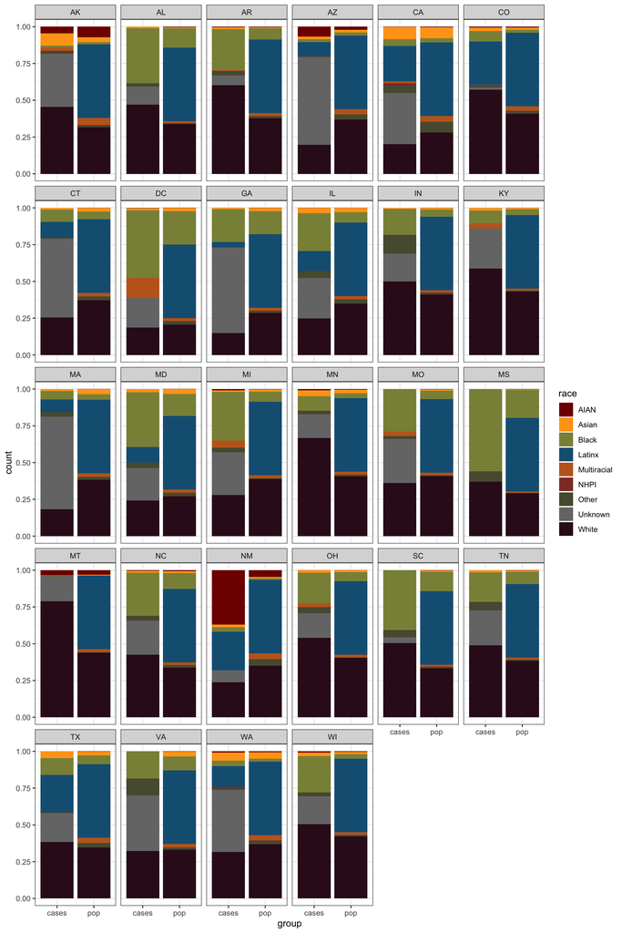

```r
cases_long_counts_start <- norm_data_total %>%
  filter(date1 == as.Date("2020-04-15")) %>%
  select(post_code, Cases_Total:Cases_Unknown) %>%
  mutate(across(Cases_Total:Cases_Unknown, ~replace_na(.x, 0))) %>%
  pivot_longer(-post_code, names_to = "race", values_to = "cases",
               names_prefix = "Cases_")

cases_long_counts_end <- norm_data_total %>%
  filter(date1 == as.Date("2021-03-07")) %>%
  select(post_code, Cases_Total:Cases_Unknown) %>%
  mutate(across(Cases_Total:Cases_Unknown, ~replace_na(.x, 0))) %>%
  pivot_longer(-post_code, names_to = "race", values_to = "cases",
               names_prefix = "Cases_")

# long pop counts
pop_long_counts_start <- norm_data_total %>%
  filter(date1 == as.Date("2020-04-15")) %>%
  select(post_code, Total_pop:Latinx_pop) %>%
  mutate(across(Total_pop:Latinx_pop, as.numeric)) %>%
  pivot_longer(-post_code, names_to = "race", values_to = "pop") %>%
  mutate(race = str_remove(race, "_pop"))

pop_long_counts_end <- norm_data_total %>%
  filter(date1 == as.Date("2021-03-07")) %>%
  select(post_code, Total_pop:Latinx_pop) %>%
  mutate(across(Total_pop:Latinx_pop, as.numeric)) %>%
  pivot_longer(-post_code, names_to = "race", values_to = "pop") %>%
  mutate(race = str_remove(race, "_pop"))

# joining the two (and pivotting again)
cases_long_counts_start <- cases_long_counts_start %>%
  left_join(pop_long_counts_start) %>%
  pivot_longer(-c(post_code, race), names_to = "group", values_to = "count")

cases_long_counts_end <- cases_long_counts_end %>%
  left_join(pop_long_counts_end) %>%
  pivot_longer(-c(post_code, race), names_to = "group", values_to = "count")

# creating stacked bars to compare by state
cases_long_counts_start %>%
  filter(race != "Total") %>%
  ggplot(aes(x = group, y = count, fill = race)) +
  scale_fill_manual(values = c("#800000FF", "#FFA319FF", "#8A9045FF", "#155F83FF", "#C16622FF", "#8F3931FF", "#58593FFF", "#767676FF", "#350E20FF")) +
  geom_col(position = "fill") +
  facet_wrap(~ post_code)
```

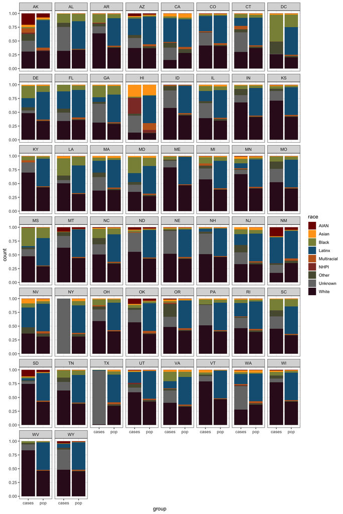

```r
cases_long_counts_end %>%
  filter(race != "Total") %>%
  ggplot(aes(x = group, y = count, fill = race)) +
    scale_fill_manual(values = c("#800000FF", "#FFA319FF", "#8A9045FF", "#155F83FF", "#C16622FF", "#8F3931FF", "#58593FFF", "#767676FF", "#350E20FF")) +
  geom_col(position = "fill") +
  facet_wrap(~ post_code)
```

Something interesting that pops up in this view is the minimal proportion of cases in Latinx communities. The proportion of community members with cases is significantly smaller for Latinx communities than the total Latinx population might suggest there would be. In several states, such as Mississippi, South Carolina, Louisiana, and Maryland, there are higher proportions of Black cases than the total Black population in each state might suggest. This suggests a potentially disproportionate experience of COVID-19 among different communities.

### Comparing COVID case prevalance with the results of the 2020 presidential election

Another question I wanted to explore with my data was whether certain states had higher rates of infection over others. I was specifically looking to test the hypothesis that more liberal states with stricter COVID-19 regulations had lower rates of infections, hospitalizations, and deaths of Black Americans compared to more conservative states with lenient COVID-19 regulations. I first looked at how the proportion of Black cases to the state’s Black population compared to 2020 election results. Then I looked at how the proportion of White cases to the state’s White population compared to 2020 election results.

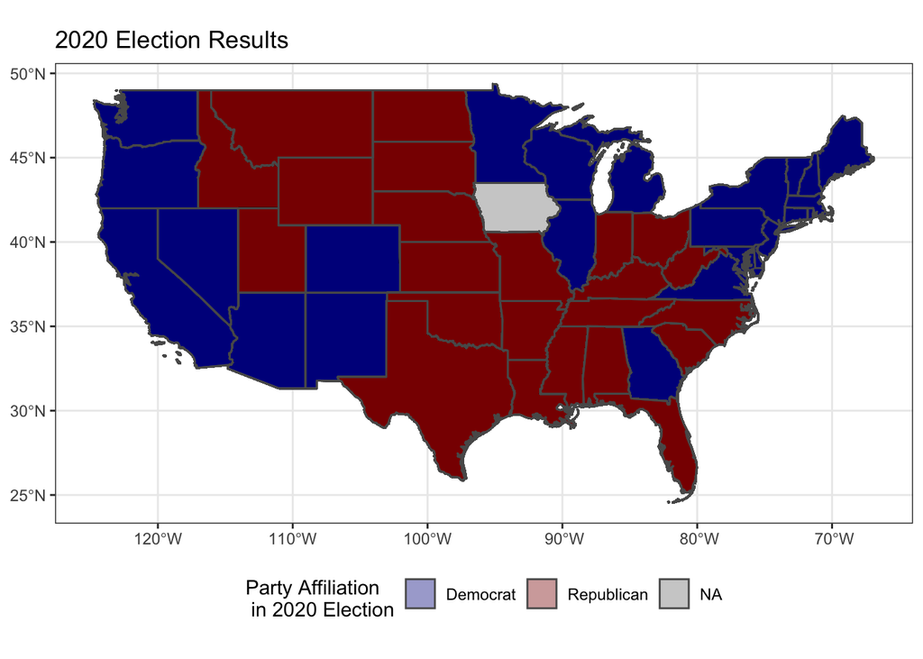

```r
party <- norm_data_total %>%
  mutate(party2020 = ifelse(post_code %in% c("AK", "AL", "AR", "FL", "ID", "IN", "IA", "KS", "KY", "LA", "MS", "MO", "MT", "NE", "NC", "ND", "OH", "OK", "SC", "SD", "TN", "TX", "UT", "WV", "WY"), "Republican", "Democrat"
  ))

usstates <- ne_states(iso_a2 = "US", returnclass = "sf")

us48 <- usstates %>%
  filter(!woe_name %in% c("Alaska", "Hawaii"))

party1 <- party %>%
  filter(!post_code %in% "AK" | !post_code %in% "HI") %>%
  mutate(postal = post_code)
us48_join <- left_join(us48, party1, by = "postal")

plot6 <- ggplot(us48_join) +
geom_sf(aes(fill= party2020), alpha = 0.4) +
  scale_fill_manual("Party Affiliation \n in 2020 Election", values = c("dark blue", "dark red")) +
  theme(legend.position = "bottom") +
  labs(title = "2020 Election Results")
plot6
```

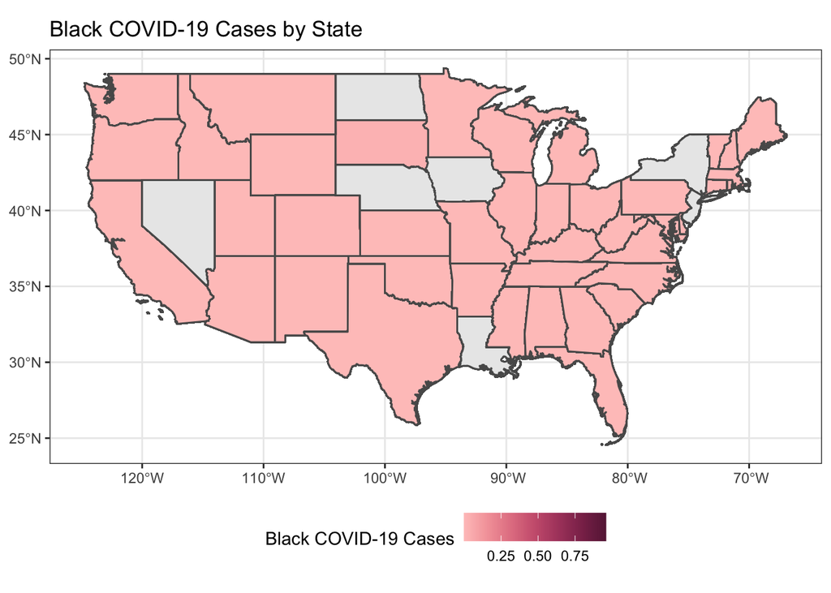

```r
plot7 <- ggplot(us48_join) +
geom_sf(aes(fill= Black_cases_norm)) +
  scale_fill_carto_c(palette = "Burg", name = "Black COVID-19 Cases") +
  theme(legend.position = "bottom") +
  labs(title = "Black COVID-19 Cases by State")
plot7
```

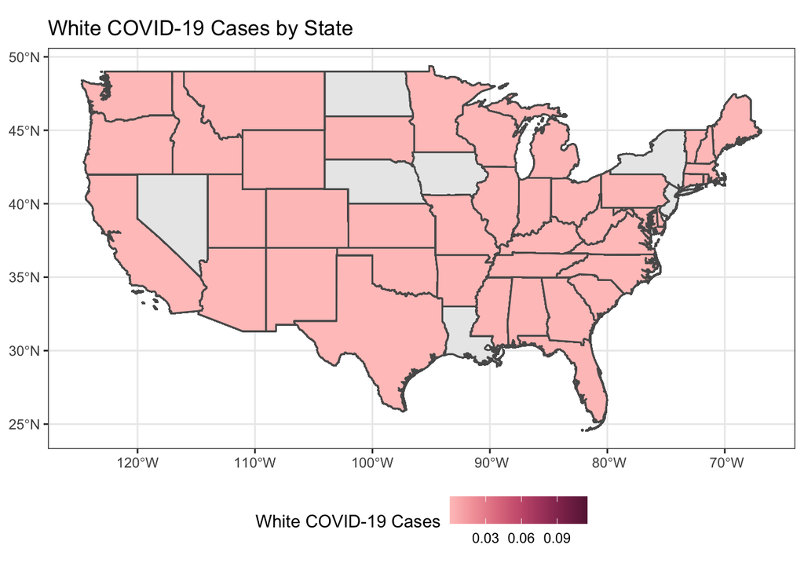

```r
plot7.1 <- ggplot(us48_join) +
geom_sf(aes(fill= White_cases_norm)) +
  scale_fill_carto_c(palette = "Burg", name = "White COVID-19 Cases") +
  theme(legend.position = "bottom") +
  labs(title = "White COVID-19 Cases by State")
plot7.1
```

## Another way of looking at the election data: A box plot

I also created a box plot to see the distribution of cases by 2020 Election results.

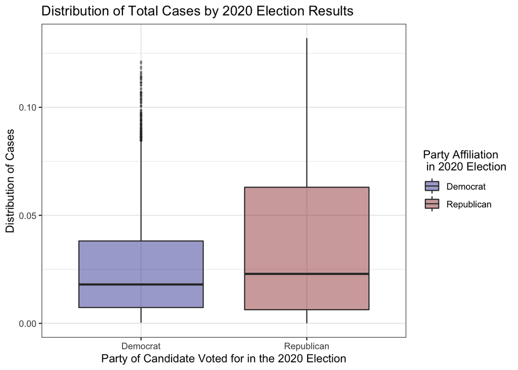

```r
#total cases in a boxplot by how the state voted in the 2020 election histogram
#indicator variable for political party

partybplot <- party %>%
  ggplot(aes(x = party2020, y = Total_cases_norm, fill = party2020)) +
  geom_boxplot(outlier.size = 0.5, alpha= 0.4) +
  scale_fill_manual("Party Affiliation \n in 2020 Election", values = c("dark blue", "dark red")) +
   labs(x = "Party of Candidate Voted for in the 2020 Election", y = "Distribution of Cases", title = "Distribution of Total Cases by 2020 Election Results ")
partybplot
```

After normalizing for population differences, the states with the higher counts of COVID cases are states that voted for the Republican candidate in the 2020 election. The interquartile range for the Republican voting states is larger, indicating more variability, but ultimately the median proportion of cases to total state population and maximum cases is higher for Republican voting states than Democrat voting states. Other factors could contribute to this higher count, but there does seem to maybe be a relationship between state voting patterns and the prevalance of COVID.

## Conclusion

# Sources

- https://www.kff.org/coronavirus-covid-19/issue-brief/covid-19-cases-and-deaths-by-race-ethnicity-current-data-and-changes-over-time/#:~:text=Total%20cumulative%20data%20show%20that,age%20by%20race%20and%20ethnicity.
- https://covidtracking.com/race/about#get-in-touch.
- https://www.archives.gov/electoral-college/2020.
- https://data.census.gov/cedsci/table?q=DP05&g=0100000US%240400000.